# Website Analytics for Toronto.ca

Thamilini P.

2022-12-07

## Ask Phase

The City of Toronto releases open data with the public. The datasets used contain information on how visitors interact with toronto.ca website.

### Task/Objective

Analyze traffic and behavior of visitors to a website to improve user’s experience.

## Prepare Phase

### Datasets License

All datasets used were made available by the [City of Toronto Open Data Portal](https://open.toronto.ca/about/) under the [Open Government Licence – Toronto](https://open.toronto.ca/open-data-license/).

### Load R Packages

```r
library(tidyverse)
library(skimr)
library(janitor)
library(lubridate)
library(ggplot2)
```

### Import dataset as dataframe

```r
Key_Metrics <- read_csv("/Users/thamiliniparamanantham/Downloads/web-analytics-monthly-report/202211/Key Metrics.csv")

Browser <- read_csv("/Users/thamiliniparamanantham/Downloads/web-analytics-monthly-report/202211/Browser.csv")

Cities <- read_csv("/Users/thamiliniparamanantham/Downloads/web-analytics-monthly-report/202211/Cities.csv")

Countries <- read_csv("/Users/thamiliniparamanantham/Downloads/web-analytics-monthly-report/202211/Countries.csv")

Hits_by_Hour_of_Day <- read_csv("/Users/thamiliniparamanantham/Downloads/web-analytics-monthly-report/202211/Hits by Hour of Day.csv")

Mobile_Devices <- read_csv("/Users/thamiliniparamanantham/Downloads/web-analytics-monthly-report/202211/Mobile Devices.csv")

New_Return_Visitors <- read_csv("/Users/thamiliniparamanantham/Downloads/web-analytics-monthly-report/202211/New vs. Return Visitors.csv")

Referring_Site <- read_csv("/Users/thamiliniparamanantham/Downloads/web-analytics-monthly-report/202211/Referring Site.csv")

Top_Pages <- read_csv("/Users/thamiliniparamanantham/Downloads/web-analytics-monthly-report/202211/Top Pages.csv")

Visits_by_Weekday <- read_csv("/Users/thamiliniparamanantham/Downloads/web-analytics-monthly-report/202211/Visits by Day of Week.csv")
```

## Process Phase

```r
skim_without_charts(Key_Metrics)
```

Data summary

| Name | Key_Metrics |
| --- | --- |
| Number of rows | 31 |
| Number of columns | 8 |
| _______________________ |  |
| Column type frequency: |  |
| numeric | 8 |
| ________________________ |  |
| Group variables | None |

**Variable type: numeric**

| skim_variable | n_missing | complete_rate | mean | sd | p0 | p25 | p50 | p75 | p100 |
| --- | --- | --- | --- | --- | --- | --- | --- | --- | --- |
| Day of Month | 1 | 0.97 | 15.50 | 8.80 | 1.00 | 8.25 | 15.50 | 22.75 | 30.00 |
| Users | 0 | 1.00 | 1029.52 | 2524.09 | 178.00 | 489.00 | 611.00 | 678.50 | 14606.00 |
| Sessions | 0 | 1.00 | 1268.06 | 3414.56 | 189.00 | 547.50 | 691.00 | 798.00 | 19641.00 |
| Views | 0 | 1.00 | 3168.77 | 8547.63 | 415.00 | 1254.50 | 1835.00 | 1999.00 | 49116.00 |
| Bounce Rate % | 0 | 1.00 | 0.62 | 0.06 | 0.54 | 0.58 | 0.61 | 0.63 | 0.77 |
| Avg Session Duration (Sec) | 0 | 1.00 | 335.82 | 60.25 | 206.43 | 305.73 | 334.00 | 359.39 | 456.80 |
| Screen Views per Session | 0 | 1.00 | 2.44 | 0.34 | 1.65 | 2.23 | 2.40 | 2.55 | 3.57 |
| Sessions (New) | 0 | 1.00 | 829.71 | 2233.51 | 131.00 | 392.50 | 445.00 | 501.00 | 12852.00 |

```r
get_dupes(Key_Metrics)
```

```
## No variable names specified - using all columns.
```

```
## No duplicate combinations found of: Day of Month, Users, Sessions, Views, Bounce Rate %, Avg Session Duration (Sec), Screen Views per Session, Sessions (New)
```

```
## # A tibble: 0 × 9
## # … with 9 variables: Day of Month <dbl>, Users <dbl>, Sessions <dbl>,
## #   Views <dbl>, Bounce Rate % <dbl>, Avg Session Duration (Sec) <dbl>,
## #   Screen Views per Session <dbl>, Sessions (New) <dbl>, dupe_count <int>
```

```r
head(Key_Metrics)
```

```
## # A tibble: 6 × 8
##   `Day of Month` Users Sessions Views `Bounce Rate %` Avg Sess…¹ Scree…² Sessi…³
##            <dbl> <dbl>    <dbl> <dbl>           <dbl>      <dbl>   <dbl>   <dbl>
## 1             NA 14606    19641 49116           0.607       334.    2.50   12852
## 2              2   776      849  2330           0.565       307.    2.74     573
## 3              7   776      896  2536           0.540       392.    2.83     540
## 4              8   762      905  2433           0.576       434.    2.69     544
## 5              1   742      816  1864           0.614       263.    2.28     555
## 6              3   705      796  1906           0.634       270.    2.39     523
## # … with abbreviated variable names ¹`Avg Session Duration (Sec)`,
## #   ²`Screen Views per Session`, ³`Sessions (New)`
```

Let define some terms:

- Bounce Rate is the percentage of users that enters a site and leaves without taking an action (like viewing other pages, clicking a link, filling a form, etc). Link to [definition](https://backlinko.com/hub/seo/bounce-rate).
- Screen Views Per Session indicates the average number of screens/pages a user views per session.
- Sessions(New) is the number of sessions that consists of new visitors to the website.

Let’s add a new column with the exact date.

```r
Key_Metrics <- Key_Metrics %>%
  mutate(Date = make_date(year = 2022,month = 11, day = `Day of Month`))
```

#### Total Sessions

Calculate total sessions for November

```r
total_sessions <- Key_Metrics %>%
  summarise(total_sessions= sum(Sessions[-1]))

total_sessions
```

```
## # A tibble: 1 × 1
##   total_sessions
##            <dbl>
## 1          19669
```

#### Total Views

```r
total_views <- Key_Metrics %>%
  summarise(total_views= sum(Views[-1]))

total_views
```

```
## # A tibble: 1 × 1
##   total_views
##         <dbl>
## 1       49116
```

#### Average Session Duration

Let’s determine the average session duration for the entire month of November.

```r
average_session_duration <- Key_Metrics %>%
  summarise(avg_session_duration = mean(`Avg Session Duration (Sec)`))

#convert to a period
seconds_to_period(average_session_duration)
```

```
## [1] "5M 35.8154709095309S"
```

So the average session duration for November 2022 was about 5 Minutes 36 Seconds.

#### Average Bounce Rate

Let’s calculate the average bounce rate.

```r
avg_bounce_rate <- Key_Metrics %>%
  summarise(avg_bounce_rate = mean(`Bounce Rate %`))

avg_bounce_rate
```

```
## # A tibble: 1 × 1
##   avg_bounce_rate
##             <dbl>
## 1           0.619
```

#### Average Screen Views per Session

Let’s calculuate the average screen views per session.

```r
avg_screen_views <- Key_Metrics %>%
  summarise(avg_screen_views = mean(`Screen Views per Session`))

avg_screen_views
```

```
## # A tibble: 1 × 1
##   avg_screen_views
##              <dbl>
## 1             2.44
```

```r
skim_without_charts(Browser)
```

Data summary

| Name | Browser |
| --- | --- |
| Number of rows | 19 |
| Number of columns | 3 |
| _______________________ |  |
| Column type frequency: |  |
| character | 1 |
| numeric | 2 |
| ________________________ |  |
| Group variables | None |

**Variable type: character**

| skim_variable | n_missing | complete_rate | min | max | empty | n_unique | whitespace |
| --- | --- | --- | --- | --- | --- | --- | --- |
| Browser Name | 1 | 0.95 | 4 | 17 | 0 | 18 | 0 |

**Variable type: numeric**

| skim_variable | n_missing | complete_rate | mean | sd | p0 | p25 | p50 | p75 | p100 |
| --- | --- | --- | --- | --- | --- | --- | --- | --- | --- |
| Sessions | 0 | 1 | 2060.68 | 5314.96 | 1 | 1.0 | 6 | 596 | 19576 |
| Views | 0 | 1 | 5160.53 | 13176.11 | 1 | 1.5 | 9 | 1410 | 49025 |

```r
get_dupes(Browser)
```

```
## No variable names specified - using all columns.
```

```
## No duplicate combinations found of: Browser Name, Sessions, Views
```

```
## # A tibble: 0 × 4
## # … with 4 variables: Browser Name <chr>, Sessions <dbl>, Views <dbl>,
## #   dupe_count <int>
```

```r
head(Browser)
```

```
## # A tibble: 6 × 3
##   `Browser Name` Sessions Views
##   <chr>             <dbl> <dbl>
## 1 <NA>              19576 49025
## 2 Chrome            14011 33876
## 3 Edge               2112  7404
## 4 Safari             2109  4588
## 5 Chrome Mobile       656  1247
## 6 Firefox             536  1573
```

The first row is empty for the Browser Name, because it contains the total Sessions and Views used with any browser.

There are 18 Unique Browser Names

```r
unique(Browser$`Browser Name`)
```

```
##  [1] NA                  "Chrome"            "Edge"
##  [4] "Safari"            "Chrome Mobile"     "Firefox"
##  [7] "Opera"             "Internet Explorer" "Samsung Browser"
## [10] "Amazon Silk"       "Opera Mobile"      "Miui Browser"
## [13] "Mqq Browser"       "Chromium"          "Yandex.browser"
## [16] "Opera Touch"       "Uc Browser"        "Iron"
## [19] "Puffin"
```

```r
skim_without_charts(Cities)
```

Data summary

| Name | Cities |
| --- | --- |
| Number of rows | 251 |
| Number of columns | 6 |
| _______________________ |  |
| Column type frequency: |  |
| character | 1 |
| numeric | 5 |
| ________________________ |  |
| Group variables | None |

**Variable type: character**

| skim_variable | n_missing | complete_rate | min | max | empty | n_unique | whitespace |
| --- | --- | --- | --- | --- | --- | --- | --- |
| City | 1 | 1 | 1 | 20 | 0 | 250 | 0 |

**Variable type: numeric**

| skim_variable | n_missing | complete_rate | mean | sd | p0 | p25 | p50 | p75 | p100 |
| --- | --- | --- | --- | --- | --- | --- | --- | --- | --- |
| Sessions | 0 | 1 | 153.06 | 1339.83 | 3.00 | 4.00 | 7.00 | 17.50 | 19641.00 |
| Views | 0 | 1 | 382.79 | 3300.91 | 2.00 | 9.00 | 19.00 | 48.00 | 49116.00 |
| Avg Session Duration (Sec) | 0 | 1 | 328.61 | 311.25 | 0.00 | 99.24 | 266.75 | 431.81 | 1847.59 |
| Bounce Rate % | 0 | 1 | 0.47 | 0.25 | 0.00 | 0.33 | 0.45 | 0.63 | 1.00 |
| Views per Session | 0 | 1 | 3.08 | 3.79 | 0.56 | 1.76 | 2.57 | 3.30 | 48.70 |

```r
get_dupes(Cities)
```

```
## No variable names specified - using all columns.
```

```
## No duplicate combinations found of: City, Sessions, Views, Avg Session Duration (Sec), Bounce Rate %, Views per Session
```

```
## # A tibble: 0 × 7
## # … with 7 variables: City <chr>, Sessions <dbl>, Views <dbl>,
## #   Avg Session Duration (Sec) <dbl>, Bounce Rate % <dbl>,
## #   Views per Session <dbl>, dupe_count <int>
```

```r
head(Cities)
```

```
## # A tibble: 6 × 6
##   City        Sessions Views `Avg Session Duration (Sec)` Bounce Rate …¹ Views…²
##   <chr>          <dbl> <dbl>                        <dbl>          <dbl>   <dbl>
## 1 <NA>           19641 49116                         334.          0.607    2.50
## 2 Toronto         7614 17489                         330.          0.637    2.30
## 3 Boydton         2757  2759                          25           0.999    1.00
## 4 North York      1310  4518                         387.          0.417    3.45
## 5 Scarborough      741  1746                         225.          0.543    2.36
## 6 Mississauga      548  1713                         362.          0.449    3.13
## # … with abbreviated variable names ¹`Bounce Rate %`, ²`Views per Session`
```

There are 250 Unique Cities

```r
skim_without_charts(Countries)
```

Data summary

| Name | Countries |
| --- | --- |
| Number of rows | 86 |
| Number of columns | 6 |
| _______________________ |  |
| Column type frequency: |  |
| character | 1 |
| numeric | 5 |
| ________________________ |  |
| Group variables | None |

**Variable type: character**

| skim_variable | n_missing | complete_rate | min | max | empty | n_unique | whitespace |
| --- | --- | --- | --- | --- | --- | --- | --- |
| Country | 1 | 0.99 | 4 | 26 | 0 | 85 | 0 |

**Variable type: numeric**

| skim_variable | n_missing | complete_rate | mean | sd | p0 | p25 | p50 | p75 | p100 |
| --- | --- | --- | --- | --- | --- | --- | --- | --- | --- |
| Sessions | 0 | 1 | 456.78 | 2692.64 | 1.00 | 1.00 | 4.00 | 12.00 | 19641.00 |
| Views | 0 | 1 | 1142.23 | 6868.69 | 1.00 | 2.25 | 8.50 | 27.00 | 49116.00 |
| Avg Session Duration (Sec) | 0 | 1 | 235.34 | 266.64 | 0.00 | 26.10 | 135.01 | 376.33 | 1244.90 |
| Bounce Rate % | 0 | 1 | 0.54 | 0.33 | 0.00 | 0.42 | 0.54 | 0.81 | 1.00 |
| Views per Session | 0 | 1 | 2.69 | 4.81 | 0.67 | 1.15 | 2.00 | 2.94 | 45.24 |

```r
get_dupes(Countries)
```

```
## No variable names specified - using all columns.
```

```
## No duplicate combinations found of: Country, Sessions, Views, Avg Session Duration (Sec), Bounce Rate %, Views per Session
```

```
## # A tibble: 0 × 7
## # … with 7 variables: Country <chr>, Sessions <dbl>, Views <dbl>,
## #   Avg Session Duration (Sec) <dbl>, Bounce Rate % <dbl>,
## #   Views per Session <dbl>, dupe_count <int>
```

```r
head(Countries)
```

```
## # A tibble: 6 × 6
##   Country        Sessions Views `Avg Session Duration (Sec)` Bounce Ra…¹ Views…²
##   <chr>             <dbl> <dbl>                        <dbl>       <dbl>   <dbl>
## 1 <NA>              19641 49116                         334.       0.607    2.50
## 2 Canada            15392 41093                         334.       0.544    2.67
## 3 United States      3392  4318                         270.       0.920    1.27
## 4 United Kingdom      125   534                         697.       0.328    4.27
## 5 India                51    95                         120.       0.608    1.86
## 6 China                49   147                         496.       0.449    3
## # … with abbreviated variable names ¹`Bounce Rate %`, ²`Views per Session`
```

```r
skim_without_charts(Hits_by_Hour_of_Day)
```

Data summary

| Name | Hits_by_Hour_of_Day |
| --- | --- |
| Number of rows | 25 |
| Number of columns | 4 |
| _______________________ |  |
| Column type frequency: |  |
| numeric | 4 |
| ________________________ |  |
| Group variables | None |

**Variable type: numeric**

| skim_variable | n_missing | complete_rate | mean | sd | p0 | p25 | p50 | p75 | p100 |
| --- | --- | --- | --- | --- | --- | --- | --- | --- | --- |
| Hour of Day | 1 | 0.96 | 11.50 | 7.07 | 0 | 5.75 | 11.5 | 17.25 | 23 |
| Sessions | 0 | 1.00 | 1612.92 | 3776.28 | 330 | 485.00 | 865.0 | 1283.00 | 19641 |
| Views | 0 | 1.00 | 3929.28 | 9473.39 | 462 | 1085.00 | 2043.0 | 3199.00 | 49116 |
| Clicks | 0 | 1.00 | 13689.52 | 33083.13 | 1032 | 2507.00 | 7485.0 | 11901.00 | 171119 |

```r
get_dupes(Hits_by_Hour_of_Day)
```

```
## No variable names specified - using all columns.
```

```
## No duplicate combinations found of: Hour of Day, Sessions, Views, Clicks
```

```
## # A tibble: 0 × 5
## # … with 5 variables: Hour of Day <dbl>, Sessions <dbl>, Views <dbl>,
## #   Clicks <dbl>, dupe_count <int>
```

```r
head(Hits_by_Hour_of_Day)
```

```
## # A tibble: 6 × 4
##   `Hour of Day` Sessions Views Clicks
##           <dbl>    <dbl> <dbl>  <dbl>
## 1            NA    19641 49116 171119
## 2            11     1442  3361  12328
## 3            14     1440  3764  14055
## 4            15     1408  3748  13935
## 5            10     1368  3340  11901
## 6            13     1365  3280  12440
```

Let’s create a column with the 12 hour time. (12 hour time is easier for viewers to read and understand)

```r
Hits_by_Hour_of_Day <- Hits_by_Hour_of_Day %>%
  arrange(`Hour of Day`) %>%
  mutate(time = case_when(
    `Hour of Day` > 12 ~ paste(`Hour of Day`-12,"PM",sep = " "),
    `Hour of Day` == 12 ~ "12 PM",
    `Hour of Day` == 0 ~ "12 AM",
    `Hour of Day` < 12 & `Hour of Day` > 0  ~ paste(`Hour of Day`,"AM",sep = " "))
  )

head(Hits_by_Hour_of_Day)
```

```
## # A tibble: 6 × 5
##   `Hour of Day` Sessions Views Clicks time
##           <dbl>    <dbl> <dbl>  <dbl> <chr>
## 1             0      491  1006   3492 12 AM
## 2             1      444   847   2506 1 AM
## 3             2      382   775   2507 2 AM
## 4             3      346   511   1361 3 AM
## 5             4      330   462   1032 4 AM
## 6             5      367   544   1342 5 AM
```

```r
skim_without_charts(New_Return_Visitors)
```

Data summary

| Name | New_Return_Visitors |
| --- | --- |
| Number of rows | 4 |
| Number of columns | 8 |
| _______________________ |  |
| Column type frequency: |  |
| character | 1 |
| numeric | 7 |
| ________________________ |  |
| Group variables | None |

**Variable type: character**

| skim_variable | n_missing | complete_rate | min | max | empty | n_unique | whitespace |
| --- | --- | --- | --- | --- | --- | --- | --- |
| New-Returning User | 1 | 0.75 | 9 | 27 | 0 | 3 | 0 |

**Variable type: numeric**

| skim_variable | n_missing | complete_rate | mean | sd | p0 | p25 | p50 | p75 | p100 |
| --- | --- | --- | --- | --- | --- | --- | --- | --- | --- |
| Sessions | 0 | 1 | 9747.00 | 8351.65 | 3.0 | 4980.00 | 9745.50 | 14512.50 | 19494.00 |
| Views | 0 | 1 | 24558.00 | 20158.32 | 3.0 | 16503.75 | 24556.50 | 32610.75 | 49116.00 |
| Clicks | 0 | 1 | 29543.50 | 24155.87 | 7.0 | 20936.50 | 29540.00 | 38147.00 | 59087.00 |
| Avg Session Duration (Sec) | 0 | 1 | 318.92 | 164.25 | 98.0 | 252.50 | 347.81 | 414.23 | 482.09 |
| Bounce Rate % | 0 | 1 | 0.68 | 0.25 | 0.4 | 0.56 | 0.67 | 0.79 | 1.00 |
| Views per Session | 0 | 1 | 2.24 | 0.96 | 1.0 | 1.83 | 2.31 | 2.72 | 3.31 |
| Users | 0 | 1 | 7585.00 | 7238.13 | 3.0 | 2140.50 | 7868.00 | 13312.50 | 14601.00 |

```r
get_dupes(New_Return_Visitors)
```

```
## No variable names specified - using all columns.
```

```
## No duplicate combinations found of: New-Returning User, Sessions, Views, Clicks, Avg Session Duration (Sec), Bounce Rate %, Views per Session, Users
```

```
## # A tibble: 0 × 9
## # … with 9 variables: New-Returning User <chr>, Sessions <dbl>, Views <dbl>,
## #   Clicks <dbl>, Avg Session Duration (Sec) <dbl>, Bounce Rate % <dbl>,
## #   Views per Session <dbl>, Users <dbl>, dupe_count <int>
```

```r
head(New_Return_Visitors)
```

```
## # A tibble: 4 × 8
##   `New-Returning User`        Sessi…¹ Views Clicks Avg S…² Bounc…³ Views…⁴ Users
##   <chr>                         <dbl> <dbl>  <dbl>   <dbl>   <dbl>   <dbl> <dbl>
## 1 <NA>                          19494 49116  59087    392.   0.612    2.52 14601
## 2 new users                     12852 27109  27913    304.   0.721    2.11 12883
## 3 returning users                6639 22004  31167    482.   0.399    3.31  2853
## 4 users not accepting cookies       3     3      7     98    1        1        3
## # … with abbreviated variable names ¹Sessions, ²`Avg Session Duration (Sec)`,
## #   ³`Bounce Rate %`, ⁴`Views per Session`
```

```r
skim_without_charts(Referring_Site)
```

Data summary

| Name | Referring_Site |
| --- | --- |
| Number of rows | 189 |
| Number of columns | 6 |
| _______________________ |  |
| Column type frequency: |  |
| character | 1 |
| numeric | 5 |
| ________________________ |  |
| Group variables | None |

**Variable type: character**

| skim_variable | n_missing | complete_rate | min | max | empty | n_unique | whitespace |
| --- | --- | --- | --- | --- | --- | --- | --- |
| Referring Domain -Initial | 1 | 0.99 | 2 | 64 | 0 | 188 | 0 |

**Variable type: numeric**

| skim_variable | n_missing | complete_rate | mean | sd | p0 | p25 | p50 | p75 | p100 |
| --- | --- | --- | --- | --- | --- | --- | --- | --- | --- |
| Sessions | 0 | 1 | 202.67 | 1627.30 | 1 | 1.00 | 2.00 | 4.00 | 19152 |
| Views | 0 | 1 | 519.75 | 4133.05 | 1 | 1.00 | 4.00 | 9.00 | 49116 |
| Avg Session Duration (Sec) | 0 | 1 | 244.46 | 607.29 | 0 | 0.00 | 16.00 | 230.00 | 6307 |
| Bounce Rate % | 0 | 1 | 0.64 | 0.39 | 0 | 0.33 | 0.75 | 1.00 | 1 |
| Views per Session | 0 | 1 | 2.24 | 3.74 | 1 | 1.00 | 1.40 | 2.33 | 49 |

```r
get_dupes(Referring_Site)
```

```
## No variable names specified - using all columns.
```

```
## No duplicate combinations found of: Referring Domain -Initial, Sessions, Views, Avg Session Duration (Sec), Bounce Rate %, Views per Session
```

```
## # A tibble: 0 × 7
## # … with 7 variables: Referring Domain -Initial <chr>, Sessions <dbl>,
## #   Views <dbl>, Avg Session Duration (Sec) <dbl>, Bounce Rate % <dbl>,
## #   Views per Session <dbl>, dupe_count <int>
```

```r
head(Referring_Site)
```

```
## # A tibble: 6 × 6
##   `Referring Domain -Initial` Sessions Views Avg Session Durat…¹ Bounc…² Views…³
##   <chr>                          <dbl> <dbl>               <dbl>   <dbl>   <dbl>
## 1 <NA>                           19152 49116                421.   0.623    2.56
## 2 '-                              9660 17361                521.   0.836    1.80
## 3 www.toronto.ca                  6607 22852                324.   0.348    3.46
## 4 open.toronto.ca                 1278  5010                777.   0.467    3.92
## 5 www.google.com                   390  1008                501.   0.574    2.58
## 6 github.com                       176   374                394.   0.568    2.12
## # … with abbreviated variable names ¹`Avg Session Duration (Sec)`,
## #   ²`Bounce Rate %`, ³`Views per Session`
```

```r
skim_without_charts(Top_Pages)
```

Data summary

| Name | Top_Pages |
| --- | --- |
| Number of rows | 251 |
| Number of columns | 8 |
| _______________________ |  |
| Column type frequency: |  |
| character | 1 |
| numeric | 7 |
| ________________________ |  |
| Group variables | None |

**Variable type: character**

| skim_variable | n_missing | complete_rate | min | max | empty | n_unique | whitespace |
| --- | --- | --- | --- | --- | --- | --- | --- |
| Page | 1 | 1 | 32 | 269 | 0 | 250 | 0 |

**Variable type: numeric**

| skim_variable | n_missing | complete_rate | mean | sd | p0 | p25 | p50 | p75 | p100 |
| --- | --- | --- | --- | --- | --- | --- | --- | --- | --- |
| Sessions | 0 | 1 | 31572.70 | 254738.74 | 3248.00 | 4809.00 | 7405.00 | 14457.50 | 4013960.00 |
| Views | 0 | 1 | 51832.16 | 495878.30 | 3483.00 | 5939.00 | 9288.00 | 18506.50 | 7847854.00 |
| Avg View Time (Sec) | 0 | 1 | 151.24 | 91.05 | 14.13 | 76.97 | 150.18 | 204.86 | 454.58 |
| Entry Page % | 0 | 1 | 0.64 | 0.25 | 0.00 | 0.45 | 0.70 | 0.84 | 1.00 |
| Exit Page % | 0 | 1 | 0.62 | 0.25 | 0.05 | 0.45 | 0.68 | 0.82 | 1.00 |
| Bounce Rate % | 0 | 1 | 0.41 | 0.25 | 0.00 | 0.19 | 0.40 | 0.60 | 0.99 |
| Views per Session | 0 | 1 | 1.30 | 0.40 | 1.01 | 1.16 | 1.21 | 1.28 | 5.03 |

```r
get_dupes(Top_Pages)
```

```
## No variable names specified - using all columns.
```

```
## No duplicate combinations found of: Page, Sessions, Views, Avg View Time (Sec), Entry Page %, Exit Page %, Bounce Rate %, Views per Session
```

```
## # A tibble: 0 × 9
## # … with 9 variables: Page <chr>, Sessions <dbl>, Views <dbl>,
## #   Avg View Time (Sec) <dbl>, Entry Page % <dbl>, Exit Page % <dbl>,
## #   Bounce Rate % <dbl>, Views per Session <dbl>, dupe_count <int>
```

```r
head(Top_Pages)
```

```
## # A tibble: 6 × 8
##   Page                    Sessi…¹  Views Avg V…² Entry…³ Exit …⁴ Bounc…⁵ Views…⁶
##   <chr>                     <dbl>  <dbl>   <dbl>   <dbl>   <dbl>   <dbl>   <dbl>
## 1 <NA>                    4013960 7.85e6   123.    1       1       0.680    1.96
## 2 City Of Toronto||www.t…  483757 5.31e5    83.3   0.919   0.817   0.750    1.10
## 3 Waste Reduction||www.t…  127114 1.57e5   305.    0.978   0.979   0.866    1.23
## 4 Services & Payments, P…  121590 2.00e5   206.    0.971   0.915   0.508    1.64
## 5 Pay Your Parking Viola…  107563 1.35e5   142.    0.405   0.825   0.267    1.25
## 6 Search Results||find.t…   90204 1.70e5    97.0   0.980   0.977   0.627    1.88
## # … with abbreviated variable names ¹Sessions, ²`Avg View Time (Sec)`,
## #   ³`Entry Page %`, ⁴`Exit Page %`, ⁵`Bounce Rate %`, ⁶`Views per Session`
```

Lets create a column with the average view time in minutes.

```r
Top_Pages <- Top_Pages %>%
  mutate(avg_view_time_mins = seconds_to_period(`Avg View Time (Sec)`))

head(Top_Pages)
```

```
## # A tibble: 6 × 9
##   Page                    Sessi…¹  Views Avg V…² Entry…³ Exit …⁴ Bounc…⁵ Views…⁶
##   <chr>                     <dbl>  <dbl>   <dbl>   <dbl>   <dbl>   <dbl>   <dbl>
## 1 <NA>                    4013960 7.85e6   123.    1       1       0.680    1.96
## 2 City Of Toronto||www.t…  483757 5.31e5    83.3   0.919   0.817   0.750    1.10
## 3 Waste Reduction||www.t…  127114 1.57e5   305.    0.978   0.979   0.866    1.23
## 4 Services & Payments, P…  121590 2.00e5   206.    0.971   0.915   0.508    1.64
## 5 Pay Your Parking Viola…  107563 1.35e5   142.    0.405   0.825   0.267    1.25
## 6 Search Results||find.t…   90204 1.70e5    97.0   0.980   0.977   0.627    1.88
## # … with 1 more variable: avg_view_time_mins <Period>, and abbreviated variable
## #   names ¹Sessions, ²`Avg View Time (Sec)`, ³`Entry Page %`, ⁴`Exit Page %`,
## #   ⁵`Bounce Rate %`, ⁶`Views per Session`
```

```r
skim_without_charts(Visits_by_Weekday)
```

Data summary

| Name | Visits_by_Weekday |
| --- | --- |
| Number of rows | 8 |
| Number of columns | 4 |
| _______________________ |  |
| Column type frequency: |  |
| character | 1 |
| numeric | 3 |
| ________________________ |  |
| Group variables | None |

**Variable type: character**

| skim_variable | n_missing | complete_rate | min | max | empty | n_unique | whitespace |
| --- | --- | --- | --- | --- | --- | --- | --- |
| Day of Week | 1 | 0.88 | 6 | 9 | 0 | 7 | 0 |

**Variable type: numeric**

| skim_variable | n_missing | complete_rate | mean | sd | p0 | p25 | p50 | p75 | p100 |
| --- | --- | --- | --- | --- | --- | --- | --- | --- | --- |
| Sessions | 0 | 1 | 4913.75 | 6012.55 | 1588 | 2211.50 | 3045.5 | 3854.00 | 19641 |
| Views | 0 | 1 | 12279.00 | 15128.00 | 3548 | 4889.00 | 7591.5 | 10421.25 | 49116 |
| Clicks | 0 | 1 | 42779.75 | 52622.53 | 12937 | 16914.75 | 27623.5 | 35515.00 | 171119 |

```r
get_dupes(Visits_by_Weekday)
```

```
## No variable names specified - using all columns.
```

```
## No duplicate combinations found of: Day of Week, Sessions, Views, Clicks
```

```
## # A tibble: 0 × 5
## # … with 5 variables: Day of Week <chr>, Sessions <dbl>, Views <dbl>,
## #   Clicks <dbl>, dupe_count <int>
```

```r
head(Visits_by_Weekday)
```

```
## # A tibble: 6 × 4
##   `Day of Week` Sessions Views Clicks
##   <chr>            <dbl> <dbl>  <dbl>
## 1 <NA>             19641 49116 171119
## 2 Tuesday           4007 10956  35773
## 3 Wednesday         3803 10243  35429
## 4 Monday            3061  7824  28713
## 5 Thursday          3030  7359  26534
## 6 Friday            2333  5185  17963
```

## Analyze and Share Phase

Let’s take a closer look at Hits_by_Hour_of_Day. The last row of Hits_by_Hour_of_Day does not contain an hour so let’s remove that

```r
Hits_by_Hour_of_Day <- slice(Hits_by_Hour_of_Day,1:24)
```

Let’s plot Hits_by_Hour_of_Day by Hour and Session to view trends.

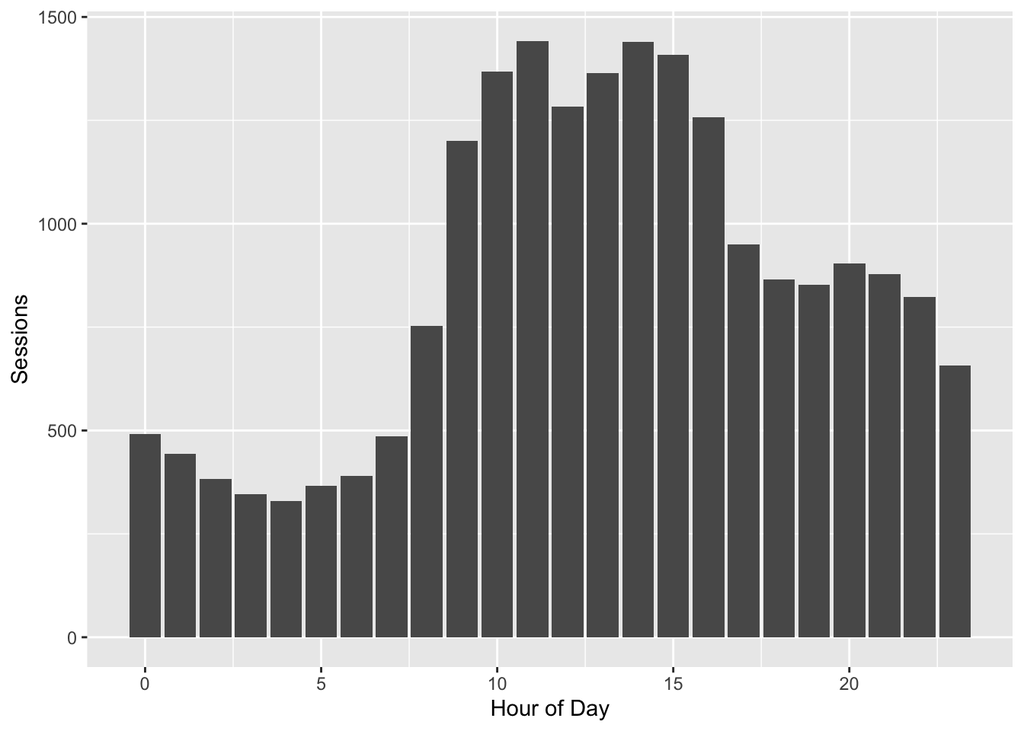

```r
ggplot(Hits_by_Hour_of_Day,aes(`Hour of Day`,Sessions))+geom_bar(stat='identity')
```

We can see that a significant amount of sessions occurred between 9 AM and 4 PM (16th Hour). Let’s calculate the total amount of sessions.

#### Sessions between 9 AM and 4 PM

```r
sessions_between_9AM_4PM <- Hits_by_Hour_of_Day %>%
  filter(`Hour of Day`>= 9 & `Hour of Day` <= 16) %>%
  summarise(session_pct = sum(Sessions))

sessions_between_9AM_4PM
```

```
## # A tibble: 1 × 1
##   session_pct
##         <dbl>
## 1       10765
```

```r
(sessions_between_9AM_4PM/total_sessions)*100
```

```
##   session_pct
## 1    54.73079
```

This means that 54.7% of total sessions occurred between 9 AM and 4 PM.

#### % of New vs. Returning Users

Let’s calculate the percentage of new users and returning users.

```r
#Remove the first row
New_Return_Visitors <- slice(New_Return_Visitors, 2:n())

total_users <- New_Return_Visitors %>%
  summarise(total_users = sum(Users))

total_users
```

```
## # A tibble: 1 × 1
##   total_users
##         <dbl>
## 1       15739
```

```r
New_Return_Visitors <- New_Return_Visitors %>%
  mutate(Users_pct = (Users/sum(Users))*100)

head(New_Return_Visitors)
```

```
## # A tibble: 3 × 9
##   New-Returning Use…¹ Sessi…² Views Clicks Avg S…³ Bounc…⁴ Views…⁵ Users Users…⁶
##   <chr>                 <dbl> <dbl>  <dbl>   <dbl>   <dbl>   <dbl> <dbl>   <dbl>
## 1 new users             12852 27109  27913    304.   0.721    2.11 12883 81.9
## 2 returning users        6639 22004  31167    482.   0.399    3.31  2853 18.1
## 3 users not acceptin…       3     3      7     98    1        1        3  0.0191
## # … with abbreviated variable names ¹`New-Returning User`, ²Sessions,
## #   ³`Avg Session Duration (Sec)`, ⁴`Bounce Rate %`, ⁵`Views per Session`,
## #   ⁶Users_pct
```

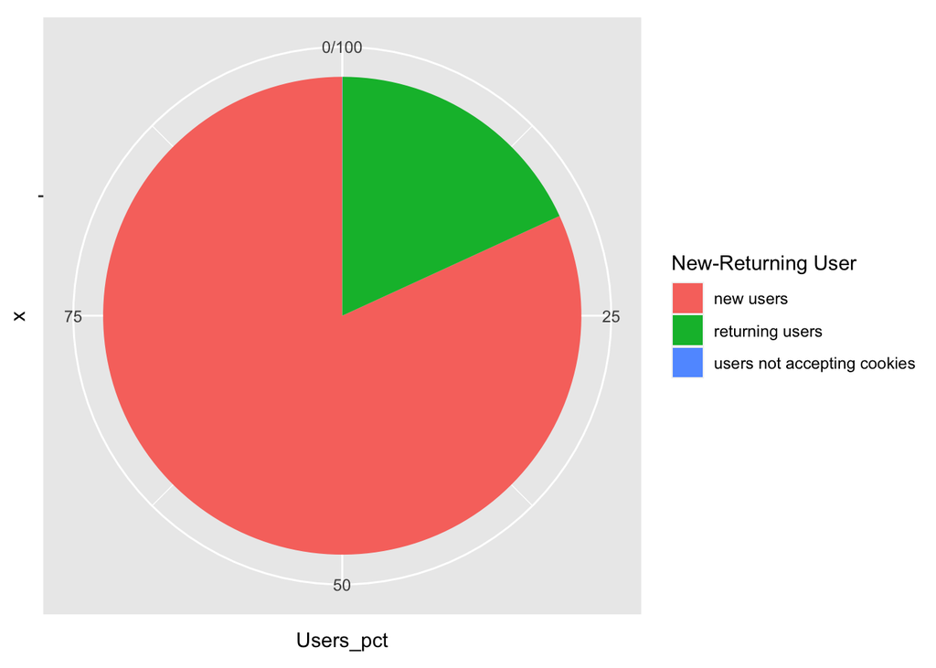

```r
ggplot(New_Return_Visitors, aes(x="", y=Users_pct, fill=`New-Returning User`)) + geom_bar(stat="identity", width=1) + coord_polar("y", start=0)
```

So 81.9% of total users are new users, while only 18.1% of total users are returning users.

#### Top 5 Browsers and Mobile Devices

```r
head(Browser)
```

```
## # A tibble: 6 × 3
##   `Browser Name` Sessions Views
##   <chr>             <dbl> <dbl>
## 1 <NA>              19576 49025
## 2 Chrome            14011 33876
## 3 Edge               2112  7404
## 4 Safari             2109  4588
## 5 Chrome Mobile       656  1247
## 6 Firefox             536  1573
```

```r
head(Mobile_Devices)
```

```
## # A tibble: 6 × 3
##   `Device Name` Sessions Views
##   <chr>            <dbl> <dbl>
## 1 <NA>              1259  2160
## 2 Iphone            1102  1857
## 3 Ipad                81   178
## 4 Galaxy S8           10    16
## 5 Galaxy A5            4     4
## 6 Galaxy J3            3     5
```

This list is useful to ensure that the website is accessible through the listed Browsers and Devices. Let calculate the % of sessions involved a Mobile Device.

```r
mobile_devices_total_session <- Mobile_Devices %>%
  summarise(mobile_devices_total_session = sum(Sessions[-1]))

mobile_devices_pct <- (mobile_devices_total_session/total_sessions)*100

mobile_devices_total_session
```

```
## # A tibble: 1 × 1
##   mobile_devices_total_session
##                          <dbl>
## 1                         1259
```

```r
mobile_devices_pct
```

```
##   mobile_devices_total_session
## 1                     6.400935
```

Only 6.4% of Total Sessions involved a Mobile Device.

#### Most Popular Page

```r
head(Top_Pages)
```

```
## # A tibble: 6 × 9
##   Page                    Sessi…¹  Views Avg V…² Entry…³ Exit …⁴ Bounc…⁵ Views…⁶
##   <chr>                     <dbl>  <dbl>   <dbl>   <dbl>   <dbl>   <dbl>   <dbl>
## 1 <NA>                    4013960 7.85e6   123.    1       1       0.680    1.96
## 2 City Of Toronto||www.t…  483757 5.31e5    83.3   0.919   0.817   0.750    1.10
## 3 Waste Reduction||www.t…  127114 1.57e5   305.    0.978   0.979   0.866    1.23
## 4 Services & Payments, P…  121590 2.00e5   206.    0.971   0.915   0.508    1.64
## 5 Pay Your Parking Viola…  107563 1.35e5   142.    0.405   0.825   0.267    1.25
## 6 Search Results||find.t…   90204 1.70e5    97.0   0.980   0.977   0.627    1.88
## # … with 1 more variable: avg_view_time_mins <Period>, and abbreviated variable
## #   names ¹Sessions, ²`Avg View Time (Sec)`, ³`Entry Page %`, ⁴`Exit Page %`,
## #   ⁵`Bounce Rate %`, ⁶`Views per Session`
```